# Preliminary Data Analysis for Cardio Good Fitness Data Set

### Observations:

1. The mean and median are different for the frequency distribution of data for age of the customer. The distribution is slightly skewed to the right (positive skew). The tail is to the right, so less number of middle aged/older customers bought the treadmill products as compared to younger people.
2. A large number of customers were around 25 years old. We can infer that young people bought treadmills more than middle-aged/older customers.
3. Among the 180 customers, the distribution of age was fairly similar for males and females. There was one outlier point present for age among the female customers - i.e. the female who was aged 50 years old was outside the whiskers of the box plot, so that data point can be considered an outlier

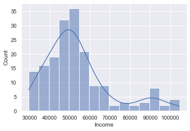

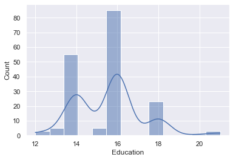

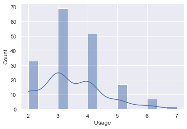

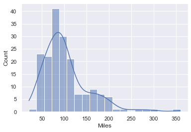

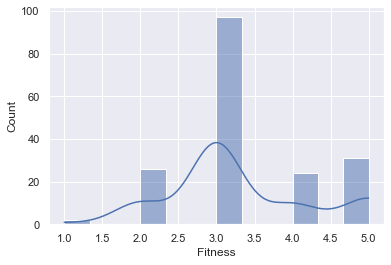

```python
# Univariate analysis section
sns.histplot(data=treadmillCustomerData, x='Income', kde=True);
plt.show()#To display multiple graphs as the output of this cell

sns.histplot(data=treadmillCustomerData, x='Education', kde=True);
plt.show()

sns.histplot(data=treadmillCustomerData, x='Usage', kde=True);
plt.show()

sns.histplot(data=treadmillCustomerData, x='Miles', kde=True);
plt.show()

sns.histplot(data=treadmillCustomerData, x='Fitness', kde=True);
plt.show()
```

### Observation

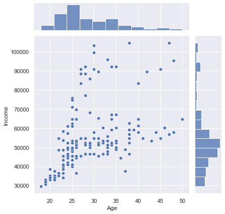

```python
#Bivariate analysis on age and income
sns.jointplot(treadmillCustomerData['Age'],treadmillCustomerData['Income']);
```

### Observations:

We can see the most of the customers are clustered around younger ages, and mostly under 70,000 dollars on the income side.

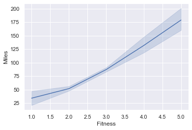

```python
#Bivariate Analysis
sns.lineplot(x='Fitness',y='Miles',data=treadmillCustomerData);
```

### Observations

Fitness versus Miles was fairly straightforward relationship. The higher the people rated themselves on the fitness scale, the more the number of miles the customers expected to walk/run each week

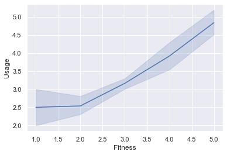

```python
#Bivariate Analysis
sns.lineplot(x='Fitness',y='Usage',data=treadmillCustomerData);
```

### Observations

Fitness versus Usage had a similar straightforward relationship. The higher the people rated themselves on the fitness scale, the more the number of times the customers expected to use the treadmills.

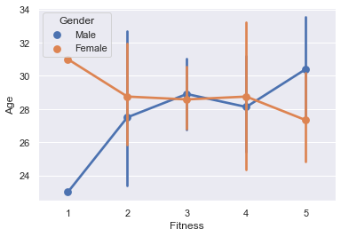

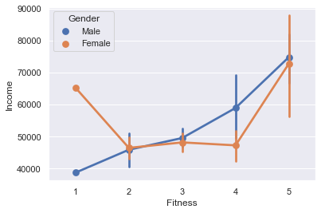

```python
#Analysis using both numerical and categorical variables
sns.pointplot(x='Fitness',y='Age',hue='Gender',data=treadmillCustomerData);
plt.show()
sns.pointplot(x='Fitness',y='Income',hue='Gender',data=treadmillCustomerData);
plt.show()
```

### Observations:

1. For fitness versus age, and categorized by gender in the first plot - we can see that females above the age of 30 happened to rate themselves low on the fitness scale, while males above the age of 30 did not. There is similar disagreement towards the other end of the fitness scale. However, both males and females around the mean and median age had a similar self-rating on the fitness scale.
2. For fitness versus income, and categorized by gender in the second plot - both males and females with higher incomes rated themselves more fit.

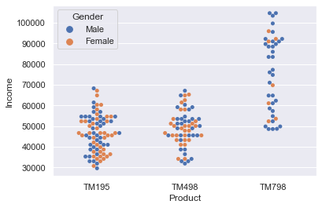

```python
#Analysis using both numerical and categorical variables
sns.swarmplot(data = treadmillCustomerData, x = 'Product',y='Income',hue='Gender');
```

### Observation

Majority of the customers who bought TM195 and TM498 products were below 70,000 dollars in income.

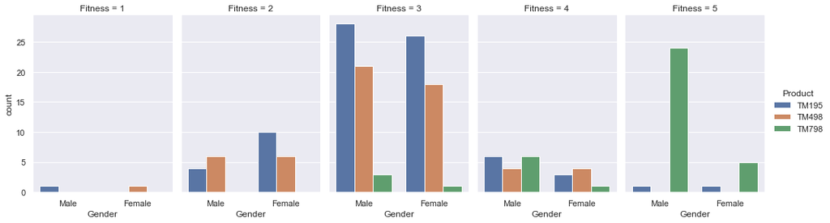

```python
#Analysis using both numerical and categorical variables
g = sns.catplot(x="Gender", hue="Product", col="Fitness",
                data=treadmillCustomerData, kind="count",
                height=4, aspect=.7);
```

### Observations

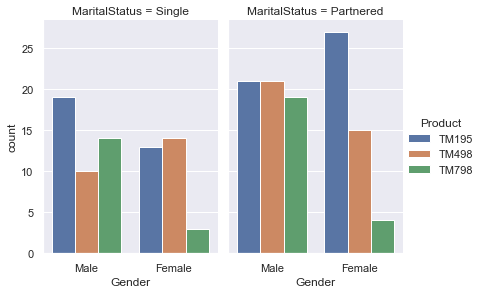

```python
#Analysis using both numerical and categorical variables
threevar = sns.catplot(x="Gender", hue="Product", col="MaritalStatus",
                data=treadmillCustomerData, kind="count",
                height=4, aspect=.7);
```

### Observations

1. Female customers who had a partner preferred product TM195 over the other two products TM498 and TM798.
2. Male single customers also preferred product TM195 over the other two products tM498 and TM798.

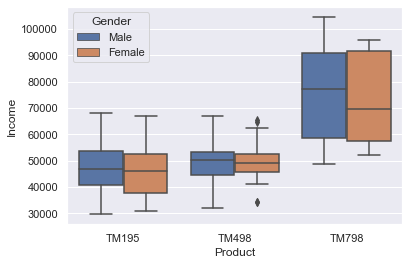

```python
#Analysis using both numerical and categorical variables
sns.boxplot(treadmillCustomerData['Product'],treadmillCustomerData['Income'],hue=treadmillCustomerData['Gender']);
```

### Observations

1. Male and female customers who had higher incomes preffered product TM798.
2. The difference in the median income of the male customers who bought TM798 as compared to the TM195 and TM498 products was approximately 30,000 dollars.

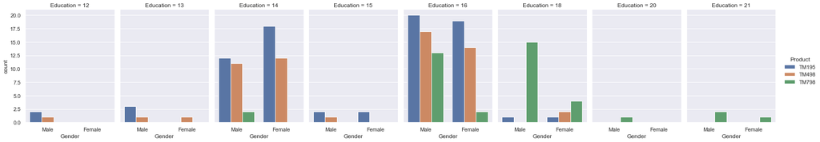

```python
threevaran = sns.catplot(x="Gender", hue="Product", col="Education",
                data=treadmillCustomerData, kind="count",
                height=4, aspect=.7);
```

### Observations

For customers who had education more than 18 years, the only product that they bought is the TM798.

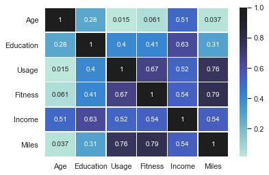

```python
#Correlation analysis among continous variables
sns.heatmap(treadmillCustomerData.corr(),annot=True, linewidths=0.5,center=1);
```

### Observations

There is some observed correlation between fitness and the miles the customers expect to walk/run every week (0.79).Also, there is a correlation relationship between fitness and usage, and income and education.

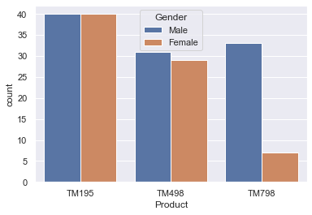

```python
sns.countplot(x="Product", hue="Gender", data=treadmillCustomerData);
```

### Observations

For product TM195, the count of male and female customers was same. For product TM498, the count of male and female customers was similar. For TM798, the count of male customers was much higher than the count of female customers.

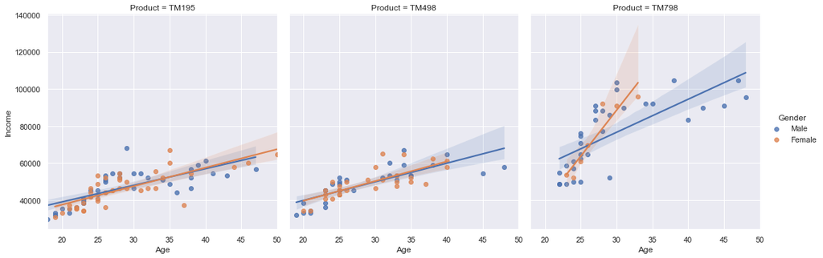

```python
sns.lmplot(x='Age',y='Income',data=treadmillCustomerData,hue='Gender',col='Product');
```

### Observations

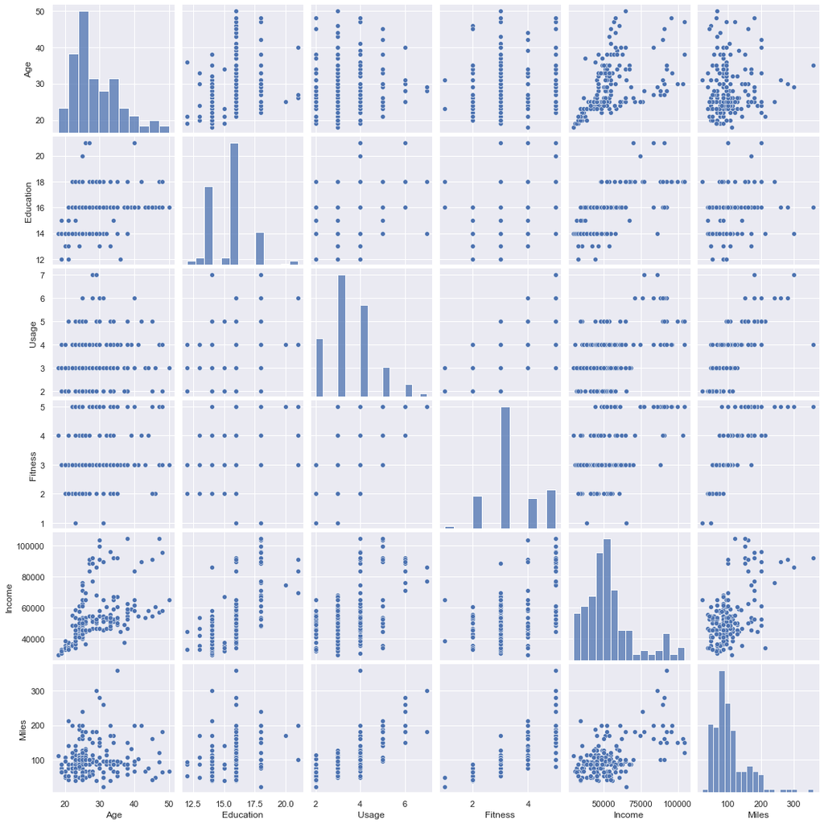

```python
#pairplot
sns.pairplot(treadmillCustomerData);
```

### Summary of key observations for the cardioFitness dataset

1. Overall, male customers outnumbered female customers for buying treadmills.
2. Younger customers (approximately in their 20s) with income in the lower half bought more treadmills when compared to older customers.
3. Customers who had a partner bought more treadmills than single customers in the dataset.
4. People who rated themselves to be in excellent shape bought more treadmills than people who rated themselves poorly on the fitness scale
5. From the data of 180 customers, females above the age of 30 rated themselves lower on the fitness scale
6. From the data of 180 customers, higher income and highly educated people rated themselves higher on the self-fitness scale.
7. The product that had been bought by most number of customers was TM195.
8. TM798 was prefered by people who rated themselves in excellent shape, and higher incomes and were highly educated. While the total number of male customers for product TM798 outnumbered the female customers, the product was bought by more number of female customers who rated themselves in excellent shape as compared to females who rated themselves lower on the fitness scale.
9. People who rated themselves higher on the fitness scale, also expected to use the treadmill for more number of times per week, and walk/run more miles as compared to people who rated themselves lower on the fitness scale.

### 9. Insights gained from the data analysis

1. TM195 is a very popular product (compared to TM498 and TM798). Since it is bought by single males, partnered females and with customers who have incomes less than 60,000 dollars - it is likely that this is a product that has an affordable price that has a wider reach.
2. TM798 is a product that can be said to appeal to higher income, highly educated males and females who rate themselves higher on the fitness scale. It is possible that the driver here is the price and the adveritzing as a "niche" product.
3. Overall, the biggest customer base are the people with incomes in the 44,000 - 58,000 dollar range.

### 10. Recommendations that can be made based on the data analysis

1. The marketing and ad campaigns should focus on creating ad content that specifically targets the customers who would tend to rate themselves low on the fitness scale. These customers are likely to belong to a category that have incomes less than 60,000 dollars, and with education in the more 12-16 years range. The ad content can include motivating and optimistic scenarios where the purchase of a treadmill improves their fitness and how they would rate themselves in the future.
2. For customers who earn less than the mean/median income for the customer base, some form of installment payment schemes might provide an incentive to boost sales, especially for a product like TM195 which would not be marketed to a non-niche audience.
3. There are no customers above the age of 50 - a strategy to overcome this would be to create specific ad campaigns that focus on safety of the product, safety with multiple kids in the household, ease of use etc.